# Karli_Balzanto_Final

Author

Karli Balzanto

```r
library(tidyverse)
library(ggplot2)
library(dplyr)
library(gt)
college <- read.csv("college.csv")
pressure <- read.csv("pressure.csv")
billboard <- read.csv("billboard.csv")
```

# Final Exam

Followed all best practices from the entire semester, showcasing skills gained through this class.

### problem 1

*hypotheses*

- $H_0:$ Mean systolic blood pressure is the same across lifestyle groups (urban, rural, suburban).
- $H_a:$ At least one lifestyle group has a different mean systolic pressure.

```r
model1 <- aov(systolic ~ lifestyle, data = pressure)
summary(model1)
```

```
             Df Sum Sq Mean Sq F value Pr(>F)
lifestyle     2  32352   16176   318.8 <2e-16 ***
Residuals   107   5429      51
---
Signif. codes:  0 '***' 0.001 '**' 0.01 '*' 0.05 '.' 0.1 ' ' 1
```

*conclusion*

- The ANOVA test produced a very small p-value (p < 0.0001). At $\alpha = 0.5$ we reject $H_0$.
- Therefore, there is strong statistical evidence that systolic blood pressure is associated with lifestyle in this Ohio sample.

### problem 2

*hypotheses*

- $H_0: \mu = 128$ (Ohio mean systolic equals U.S. mean)
- $H_a: \mu \ne 128$

```r
t.test(pressure$systolic, mu = 128)
```

```
    One Sample t-test

data:  pressure$systolic
t = -26.236, df = 109, p-value < 2.2e-16
alternative hypothesis: true mean is not equal to 128
95 percent confidence interval:
 77.90905 84.94549
sample estimates:
mean of x
 81.42727
```

*conclusion*

- The test produced a very small p-value (p < 0.001). At $\alpha = 0.5$, we reject $H_0$.
- Therefore, the data provides strong evidence that Ohioans differ from the national average systolic blood pressure of 128.

### problem 3

*hypotheses*

- $H_0: \beta_1 = 0$ (acceptance rate does not explain graduation rate)
- $H_1: \beta_1 \ne 0$

```r
college$Accept <- as.character(college$Accept)

for (i in 1:length(college$Accept)) {
  value <- college$Accept[i]
  percent_number <- substring(value, 1, nchar(value) - 1)
  college$Accept[i] <- as.numeric(percent_number) / 100}

college$Accept <- as.numeric(college$Accept)
college$Grad.Rate <- as.numeric(college$Grad.Rate)
college$Grad.Rate <- as.numeric(college$Grad.Rate)

model2 <- lm(Grad.Rate ~ Accept, data = college)
summary(model2)
```

```
Call:
lm(formula = Grad.Rate ~ Accept, data = college)

Residuals:
    Min      1Q  Median      3Q     Max
-43.620 -13.292   1.358  12.881  34.541

Coefficients:
            Estimate Std. Error t value Pr(>|t|)
(Intercept)  64.4781     2.4349  26.480   <2e-16 ***
Accept        0.5084     0.7808   0.651    0.517
---
Signif. codes:  0 '***' 0.001 '**' 0.01 '*' 0.05 '.' 0.1 ' ' 1

Residual standard error: 17.8 on 98 degrees of freedom
Multiple R-squared:  0.004307,  Adjusted R-squared:  -0.005853
F-statistic: 0.4239 on 1 and 98 DF,  p-value: 0.5165
```

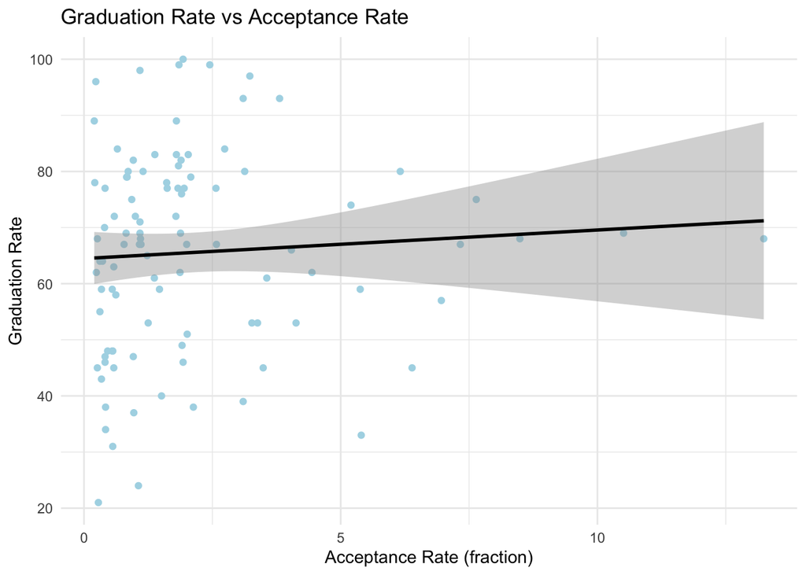

```r
ggplot(college,
       aes(x = Accept,
           y = Grad.Rate)) +
  geom_point(color = "lightblue") +
  geom_smooth(method = "lm", color = "black") +
  labs(title = "Graduation Rate vs Acceptance Rate",
       x = "Acceptance Rate (fraction)",
       y = "Graduation Rate") +
  theme_minimal()
```

### problem 4

*equation*

- $GradRate = \beta_0 + [\beta_1 * Accept] + [\beta_2 * Public]$
  - where 1 for public & 0 for private

```r
college$Public <- NA
college$Public[college$Private == "Yes"] <- 0 #private
college$Public[college$Private == "No"]  <- 1 #public

model3 <- lm(Grad.Rate ~ Accept + Public, data = college)
summary(model3)
```

```
Call:
lm(formula = Grad.Rate ~ Accept + Public, data = college)

Residuals:
    Min      1Q  Median      3Q     Max
-45.799  -8.809   0.805  11.056  38.446

Coefficients:
            Estimate Std. Error t value Pr(>|t|)
(Intercept)  66.2194     2.2614  29.283  < 2e-16 ***
Accept        2.0689     0.7947   2.603   0.0107 *
Public      -18.0792     4.0349  -4.481 2.04e-05 ***
---
Signif. codes:  0 '***' 0.001 '**' 0.01 '*' 0.05 '.' 0.1 ' ' 1

Residual standard error: 16.28 on 97 degrees of freedom
Multiple R-squared:  0.1751,    Adjusted R-squared:  0.158
F-statistic: 10.29 on 2 and 97 DF,  p-value: 8.844e-05
```

*interpretation*

- $\beta_0$: Predicted graduation rate for a private college with 0 acceptance rate.
- $\beta_1$: Change in graduation rate for every unit increase in acceptance rate.
- $\beta_2$: Difference between public and private colleges, holding acceptance rate constant.(public - private)

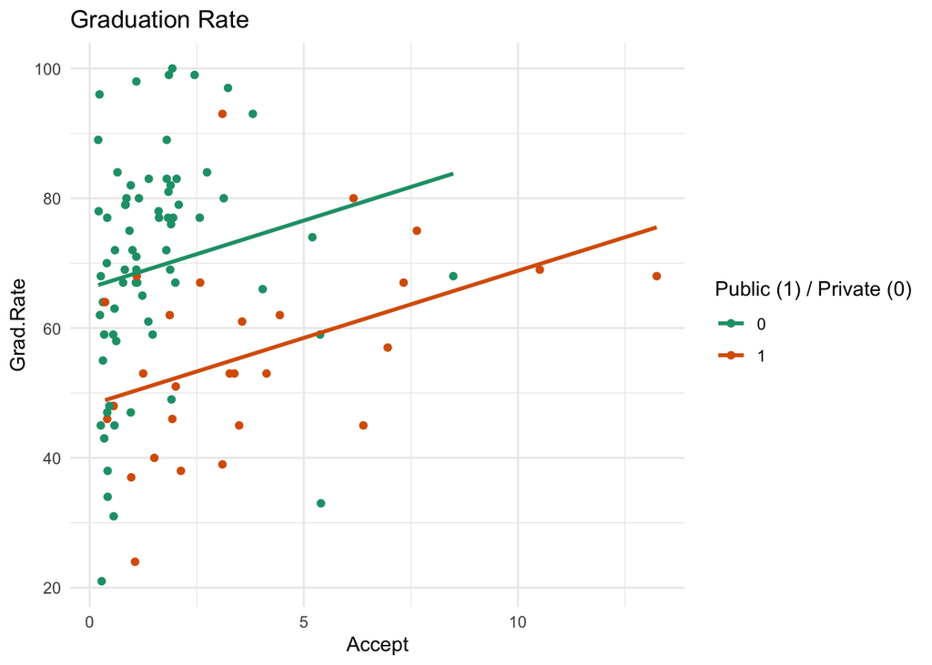

```r
ggplot(college,
       aes(x = Accept,
           y = Grad.Rate,
           color = factor(Public))) +
  geom_point() +
  geom_smooth(method = "lm", se = FALSE) +
  scale_color_brewer(palette = "Dark2") +
  labs(color = "Public (1) / Private (0)",
       title = "Graduation Rate") +
  theme_minimal()
```

*predicted graduation rate*

```r
b0 <- coef(model3)[1]
b1 <- coef(model3)[2]
b2 <- coef(model3)[3]

#accept val = 0.85
#public val = 0
predicted_value <- b0 + b1 * 0.85 + b2 * 0
predicted_value
```

```
(Intercept)
   67.97793
```

### problem 5

*write-up*

- I dug into the Billboard #1 songs data set to see how songs reaching the top varied across years and decades. The data shows that most #1 hits only stay at the top for a few weeks, but a few songs break out and stay way longer — those tracks stand out in almost any decade. When I grouped the songs by decade, I noticed some decades have more entries than others; that likely comes from how the charts were tracked and how music was released over time. I picked the song with the longest run at #1 in the data set and highlighted it on the scatter so you can see how unusual it is compared to most #1’s. Overall, the data set tells a story of consistent short-term hits with rare long-term blockbusters.

*visuals*

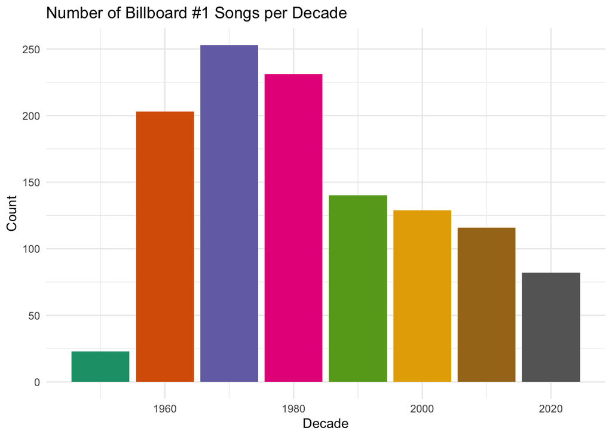

```r
#1: Number of #1 Songs per Decade
billboard$date <- as.character(billboard$date)
billboard$year <- rep(NA, length(billboard$date))
for (i in 1:length(billboard$date)) {
  billboard$year[i] <- as.numeric(substring(billboard$date[i], 1, 4))}

billboard$decade <- (billboard$year %/% 10) * 10

ggplot(billboard,
       aes(x = decade,
           fill = factor(decade))) +
  geom_bar(show.legend = FALSE) +
  labs(title = "Number of Billboard #1 Songs per Decade",
       x = "Decade",
       y = "Count") +
  scale_fill_brewer(palette = "Dark2") +
  theme_minimal()
```

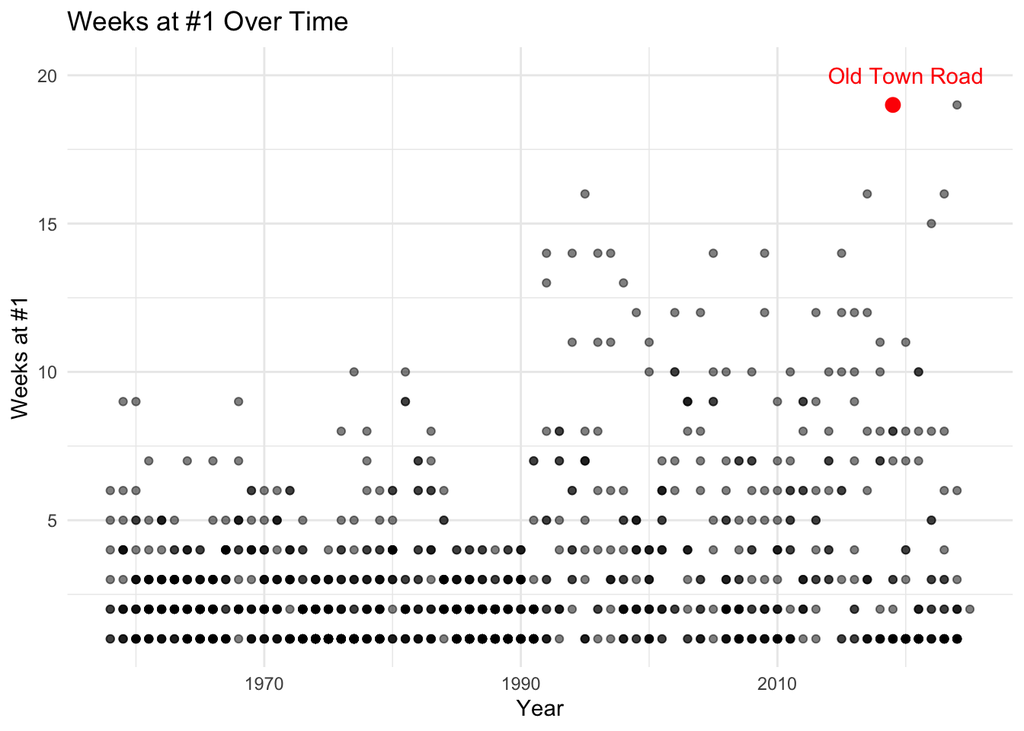

```r
#2: Weeks at #1 Over Time with Highlighted Song
highlight <- billboard[order(-billboard$weeks_at_number_one), ][1, ]

ggplot(billboard,
       aes(x = year,
           y = weeks_at_number_one)) +
  geom_point(alpha = 0.5) +
  geom_point(data = highlight,
             color = "red",
             size = 3) +
  annotate("text",
           x = highlight$year + 1,
           y = highlight$weeks_at_number_one + 1,
           label = highlight$song,
           color = "red") +
  labs(title = "Weeks at #1 Over Time",
       x = "Year",
       y = "Weeks at #1") +
  theme_minimal()
```

```r
#3: Top 10 Longest #1 Songs
top10 <- billboard %>%
  arrange(desc(weeks_at_number_one)) %>%
  select(song, artist, weeks_at_number_one) %>%
  slice(1:10) %>%
  gt()
top10
```

| song | artist | weeks_at_number_one |
| --- | --- | --- |
| Old Town Road | Lil Nas X ft. Billy Ray Cyrus | 19 |
| A Bar Song (Tipsy) | Shaboozey | 19 |
| One Sweet Day | Mariah Carey & Boyz II Men | 16 |
| Despacito | Luis Fonsi & Daddy Yankee ft. Justin Bieber | 16 |
| Last Night | Morgan Wallen | 16 |
| As It Was | Harry Styles | 15 |
| I Will Always Love You | Whitney Houston | 14 |
| I'll Make Love to You | Boyz II Men | 14 |
| Macarena (Bayside Boys Mix) | Los del Río | 14 |
| Candle in the Wind 1997 | Elton John | 14 |

### problem 6

*GitHub* put problem 5 into GitHub